# Tutorial 10: Building a Safety Knowledge Assistant with RAG

CHEE4003: Special Topics A - Artificial Intelligence in Chemical Engineering

Published

October 8, 2026

# What is RAG?

Imagine asking an AI assistant, *“What PPE is required when handling acetone?”* or *“What should I do if sodium hydroxide splashes into my eyes?”* A large language model (LLM) may provide a reasonable answer, but how do we know the response is based on the specific Safety Data Sheet (SDS) used in our laboratory? More importantly, how can we verify where the information came from?

Large language models (LLMs) can answer a wide range of questions using knowledge learned during training. However, they do not automatically have access to specialised engineering documents such as operating manuals, technical reports, or Safety Data Sheets (SDSs). As a result, responses may be incomplete, outdated, or unsupported by evidence from the documents we wish to use.

To address this limitation, we can use **Retrieval-Augmented Generation (RAG)**. Rather than relying solely on the LLM’s pre-trained knowledge, a RAG system first searches a collection of documents for information relevant to a user’s question. The retrieved information is then supplied to the LLM, enabling it to generate an answer grounded in the source material.

## RAG Workflow

In this tutorial, you will build a **Safety Knowledge Assistant** that answers questions using Safety Data Sheets. The assistant will retrieve relevant sections from SDS documents and use them to generate evidence-based responses, allowing users to trace answers back to the original safety documentation.

Figure 1 shows the overall architecture of the system developed in this tutorial. Safety Data Sheets are loaded and divided into text chunks, converted into numerical embeddings, and stored in a vector database. When a user asks a question, the system retrieves the most relevant document sections and provides them to the language model to generate a grounded response.

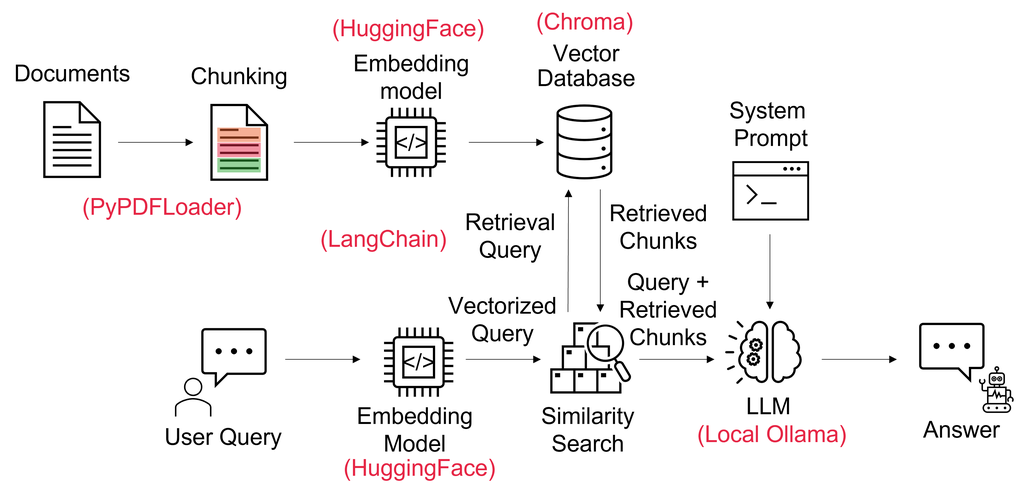

Figure 1: Overview of the RAG workflow used in this tutorial.

The knowledge base contains the following SDSs.

| Chemical | Supplier | SDS |
| --- | --- | --- |
| Acetone | Sigma-Aldrich | PDF |
| Sodium Hydroxide | Fisher Scientific | PDF |

**NoteLearning objectives**

After completing this tutorial, you will be able to:

1. explain the purpose of Retrieval-Augmented Generation (RAG) and how it improves question answering;
2. distinguish between responses generated by a standalone LLM and a RAG-based system;
3. load and process PDF documents for use in a retrieval pipeline;
4. split documents into chunks suitable for semantic search and retrieval;
5. generate embeddings that capture the meaning of document text;
6. build and query a vector database using similarity search;
7. retrieve relevant document passages in response to user questions;
8. integrate retrieval and generation to create a grounded question-answering assistant; and
9. evaluate the accuracy, completeness, and source grounding of responses generated using RAG.

## LLMs, Ollama, and Google Colab quickstart

This tutorial uses a **large language model (LLM)** through the [Ollama](https://ollama.com/) framework. Ollama provides a simple way to run open-source language models locally while offering an interface similar to cloud-based LLM services. Throughout the tutorial, the LLM will be used to answer questions and generate responses based on information retrieved from SDSs.

The performance of an LLM depends on several factors, including:

- the size of the language model;
- the amount of available memory; and
- the computational hardware available.

For faster performance, Google Colab can provide access to a Graphics Processing Unit (**GPU**). To enable a GPU, select **Runtime → Change runtime type**, choose a GPU hardware accelerator, and reconnect the runtime.

## What Are Embeddings?

Although LLMs appear to work directly with text, they cannot process words and sentences in their original form. Instead, text must first be converted into **embeddings**: numerical vectors that capture the meaning of words, phrases, or documents.

Embeddings allow text with similar meanings to be represented by similar numerical patterns. This makes it possible to compare pieces of text mathematically and identify semantic relationships between them. For example, the words *methanol* and *ethanol* are chemically related and will typically have more similar embeddings than unrelated words such as *basketball*.

Embeddings are a fundamental component of modern AI systems and are widely used in applications such as semantic search, recommendation systems, and **Retrieval-Augmented Generation (RAG)**. In a RAG system, embeddings help identify documents that are most relevant to a user’s question before the LLM generates a response.

In the following activities, you will generate embeddings using a pre-trained transformer model and explore how embeddings can be used to measure semantic similarity between different pieces of text.

### Task 1 : Generating Embeddings with a Transformer Model

In this task, you will use a pre-trained transformer model to convert text into **embeddings** (numerical vectors that capture semantic meaning). You will also explore how text is **tokenized** before being processed by the model.

Copy the code below into your Python script (or Jupyter Notebook) and run it. Examine the generated tokens, token IDs, and embedding vector. Try replacing `"reactor"` with other engineering terms and compare the results.

```
word_embeddings.py
```

```python
"""
📦 Install required packages (run once in terminal)

pip install langchain-huggingface
pip install torch
pip install transformers
pip install sentence-transformers
"""

# ---------------------------------------------------
# STEP 1: Import libraries
# ---------------------------------------------------

from langchain_huggingface import HuggingFaceEmbeddings
from transformers import AutoTokenizer


# ---------------------------------------------------
# STEP 2: Create embeddings
# ---------------------------------------------------

# This model converts text → embeddings (vectors of meaning)
model_name = "BAAI/bge-small-en"

# Load embedding model (used to generate vectors)
emb = HuggingFaceEmbeddings(
    model_name=model_name,
    model_kwargs={"device": "cpu"},              # run on CPU
    encode_kwargs={"normalize_embeddings": True} # normalize vectors for similarity
)

# Load tokenizer (used to split text into tokens)
tokenizer = AutoTokenizer.from_pretrained(model_name)


# ---------------------------------------------------
# STEP 3: Define input text
# ---------------------------------------------------

# Example word (try changing this to see different behavior)
text = "reactor"


# ---------------------------------------------------
# STEP 4: Tokenization
# ---------------------------------------------------

# The tokenizer splits text into pieces called "tokens"
# These are the units the model actually processes
tokens = tokenizer.tokenize(text)

# Each token is mapped to a unique numerical ID
token_ids = tokenizer.convert_tokens_to_ids(tokens)

print("Tokens:", tokens)
print("Token IDs:", token_ids)

# ---------------------------------------------------
# STEP 5: Convert text → embedding (vector)
# ---------------------------------------------------

# The embedding model converts the text into a vector of numbers
# This vector represents the *meaning* of the text
vector = emb.embed_query(text)

# Print only the first few values (vector is usually long)
print("Embedding (first 5 values):", vector[:5])

# Print the size of the vector (dimension)
print("Embedding dimension:", len(vector))
```

#### Questions

1. How many tokens were generated for the word *reactor*?
2. What happens when you replace *reactor* with a phrase such as *chemical engineering reactor*?
3. What is the dimensionality of the embedding vector?
4. Why might embeddings be useful for retrieving relevant documents in a RAG system?

### Task 2 : Comparing Embeddings Using Cosine Similarity

In this task, you will use a pre-trained transformer model to generate **embeddings** for different words and compare them using **cosine similarity**. Cosine similarity measures how closely related two embeddings are in meaning, with values closer to **1** indicating greater semantic similarity.

The cosine similarity between two embeddings, $\mathbf{a}$ and $\mathbf{b}$, is calculated as:

$$\text{Cosine Similarity}
=
\frac{\mathbf{a}\cdot\mathbf{b}}
{\|\mathbf{a}\|\|\mathbf{b}\|}$$

where $\mathbf{a}\cdot\mathbf{b}$ is the dot product and $\|\mathbf{a}\|$ and $\|\mathbf{b}\|$ are the magnitudes of the two vectors. When embeddings are normalised, the dot product is equal to the cosine similarity.

Copy the code below into your Python script (or Jupyter Notebook) and run it. Examine the similarity scores between the different words. Notice how related terms such as `"Methanol"` and `"Ethanol"` produce higher similarity scores than unrelated terms such as `"Basketball"`. Try replacing the words with other engineering terms and compare the results.

```
cosine_similarity.py
```

```python
"""
📦 Install required packages (run once in terminal)

pip install langchain-huggingface
pip install torch
pip install transformers
pip install sentence-transformers

"""
# ---------------------------------------------------
# STEP 1: Import libraries
# ---------------------------------------------------

# Numerical operations (dot product, norms)
import numpy as np

# Convert text into embeddings
from langchain_huggingface import HuggingFaceEmbeddings

# Load embedding model
emb = HuggingFaceEmbeddings(
    model_name="BAAI/bge-small-en",
    model_kwargs={"device": "cpu"},
    encode_kwargs={"normalize_embeddings": True} # Normalize vectors
)

# Convert words into embeddings
v1 = emb.embed_query("Methanol")
v2 = emb.embed_query("Ethanol")
v3 = emb.embed_query("Basketball")

# Similarity function
# Because embeddings are normalized,
# dot product = cosine similarity
def similarity(a, b):
    return np.dot(a, b)

# Compare words
print("\n=== COSINE SIMILARITY ===")
print("Methanol vs Methanol:", similarity(v1, v1))
print("Methanol vs Ethanol:", similarity(v1, v2))
print("Methanol vs Basketball:", similarity(v1, v3))
```

#### Questions

1. Which pair of words produced the highest similarity score?
2. Why is the similarity score between *Methanol* and *Methanol* close to 1?
3. How does the similarity between *Methanol* and *Ethanol* compare with the similarity between *Methanol* and *Basketball*?
4. Replace the example words with other engineering terms. Which terms produce the highest similarity scores?

## Build RAG in Colab

The previous activities introduced **embeddings** and **cosine similarity**, which underpin semantic search and document retrieval in RAG systems. In this section, you will apply these concepts to build a complete **RAG-based Safety Knowledge Assistant** capable of answering questions using information retrieved directly from SDSs.

### Task 3 : Build a RAG-based Safety Knowledge Assistant

Before beginning, review the SDS documents and familiarise yourself with the types of information they contain, including hazards, personal protective equipment (PPE), first-aid measures, handling procedures, storage requirements, and emergency response guidance.

To get started, download the following Google Colab notebook:

Download the Google Colab notebook (.ipynb)

Open the notebook in Google Colab and complete the activities provided. Throughout the notebook, you will develop a **RAG-based Safety Knowledge Assistant** that can:

- load PDF documents;
- split documents into manageable text chunks;
- generate embeddings for semantic search;
- store embeddings in a vector database; and
- retrieve relevant information to generate grounded responses to user questions.

### Task 4 : Compare a standalone LLM with a RAG system

Once you have completed the notebook, compare the responses generated by:

- a standalone LLM using the **Ollama Desktop** chat interface; and
- your **RAG-based Safety Knowledge Assistant**.

Use the same questions in both systems and compare the responses produced. The standalone LLM relies solely on its pre-trained knowledge, whereas the RAG assistant retrieves information directly from the SDS documents before generating a response.

**TipInstalling Ollama Desktop**

To compare your RAG assistant against a standalone large language model (LLM), install **Ollama Desktop** on your computer.

1. Visit https://ollama.com.
2. Download and install Ollama for your operating system.
3. Launch Ollama Desktop.
4. Download a model (e.g., **Llama 3.2**).
5. Open the chat interface and ask the same questions that you submit to your RAG-based Safety Knowledge Assistant.

Comparing the outputs from both systems allows you to evaluate how document retrieval affects the accuracy, completeness, and source grounding of responses.

### Task 5 : Investigate the acetone SDS

Using both the **Ollama Desktop** chat interface and your **RAG-based Safety Knowledge Assistant**, answer the following questions:

1. What personal protective equipment (PPE) is required when handling acetone?
2. Is acetone flammable? If so, what hazards does this present?
3. What immediate action should be taken following eye contact with acetone?
4. What first-aid measures should be taken after skin contact?
5. How should acetone be stored?
6. What firefighting measures are recommended in the event of a fire involving acetone?
7. What should be done in the event of an accidental spill or release?
8. What exposure controls are recommended when handling acetone?

Compare and discuss any similarities and differences between the responses generated by the two systems.

### Task 6 : Investigate the sodium hydroxide SDS

Using both the **Ollama Desktop** chat interface and your **RAG-based Safety Knowledge Assistant**, answer the following questions:

1. What hazards are associated with sodium hydroxide?
2. What personal protective equipment (PPE) is required when handling sodium hydroxide?
3. What immediate action should be taken following eye contact?
4. What first-aid measures should be taken after skin contact?
5. How should sodium hydroxide be stored?
6. What firefighting measures are recommended in the event of a fire involving sodium hydroxide?
7. What should be done in the event of an accidental spill or release?
8. What exposure controls are recommended when handling sodium hydroxide?

Compare and discuss any similarities and differences between the responses generated by the two systems.

## Conclusion

In this tutorial, you built a **Safety Knowledge Assistant** using **Retrieval-Augmented Generation (RAG)** and Safety Data Sheets (SDSs). You loaded documents, generated embeddings, created a vector database, and developed a chatbot capable of retrieving relevant information from safety documentation. Beyond safety documentation, the same techniques can be applied to operating manuals, technical reports, standard operating procedures, and other engineering knowledge sources.

By comparing responses from a standalone LLM and a RAG-based assistant, you observed how retrieval can improve the accuracy, completeness, and source grounding of AI-generated answers. These techniques form the foundation of many modern AI systems used to access and query technical knowledge bases.

## Sources

- [Hugging Face](https://huggingface.co/)
- [Ollama](https://ollama.com/)
- [Run Ollama in Colab](https://colab.research.google.com/github/5aharsh/collama/blob/main/Ollama_Setup.ipynb)